# About Dataset

salaries dataset generally provides information about the employees of an organization in relation to their compensation. It typically includes details such as how much each employee is paid (their salary), their job titles, the departments they work in, and possibly additional information like their level of experience, education, and employment history within the organization.

# Features

- 'Id'
- 'EmployeeName'
- 'JobTitle'
- 'BasePay'
- 'OvertimePay'
- 'OtherPay'
- 'Benefits'
- 'TotalPay' -> salary
- 'TotalPayBenefits'
- 'Year'
- 'Notes'
- 'Agency'
- 'Status'

# Tasks

1. **Basic Data Exploration**: Identify the number of rows and columns in the dataset, determine the data types of each column, and check for missing values in each column.
2. **Descriptive Statistics**: Calculate basic statistics mean, median, mode, minimum, and maximum salary, determine the range of salaries, and find the standard deviation.
3. **Data Cleaning**: Handle missing data by suitable method with explain why you use it.
4. **Basic Data Visualization**: Create histograms or bar charts to visualize the distribution of salaries, and use pie charts to represent the proportion of employees in different departments.
5. **Grouped Analysis**: Group the data by one or more columns and calculate summary statistics for each group, and compare the average salaries across different groups.
6. **Simple Correlation Analysis**: Identify any correlation between salary and another numerical column, and plot a scatter plot to visualize the relationship.
7. **Summary of Insights**: Write a brief report summarizing the findings and insights from the analyses.

# Very Important Note

There is no fixed or singular solution for this assignment, so if anything is not clear, please do what you understand and provide an explanation.

```python
import pandas as pd
import numpy  as np

# Load your dataset
df = pd.read_csv('Salaries.csv')
df.head()
```

|  | Id | EmployeeName | JobTitle | BasePay | OvertimePay | OtherPay | Benefits | TotalPay | TotalPayBenefits | Year | Notes | Agency | Status |
| --- | --- | --- | --- | --- | --- | --- | --- | --- | --- | --- | --- | --- | --- |
| 0 | 1 | NATHANIEL FORD | GENERAL MANAGER-METROPOLITAN TRANSIT AUTHORITY | 167411.18 | 0.00 | 400184.25 | NaN | 567595.43 | 567595.43 | 2011 | NaN | San Francisco | NaN |
| 1 | 2 | GARY JIMENEZ | CAPTAIN III (POLICE DEPARTMENT) | 155966.02 | 245131.88 | 137811.38 | NaN | 538909.28 | 538909.28 | 2011 | NaN | San Francisco | NaN |
| 2 | 3 | ALBERT PARDINI | CAPTAIN III (POLICE DEPARTMENT) | 212739.13 | 106088.18 | 16452.60 | NaN | 335279.91 | 335279.91 | 2011 | NaN | San Francisco | NaN |
| 3 | 4 | CHRISTOPHER CHONG | WIRE ROPE CABLE MAINTENANCE MECHANIC | 77916.00 | 56120.71 | 198306.90 | NaN | 332343.61 | 332343.61 | 2011 | NaN | San Francisco | NaN |
| 4 | 5 | PATRICK GARDNER | DEPUTY CHIEF OF DEPARTMENT,(FIRE DEPARTMENT) | 134401.60 | 9737.00 | 182234.59 | NaN | 326373.19 | 326373.19 | 2011 | NaN | San Francisco | NaN |

# Task 1

```python
print("the number of rows: ", df.shape[0])
print("the number of cols: ", df.shape[1])
```

```
the number of rows:  148654
the number of cols:  13
```

```python
columns = df.columns

for column in columns:
    print('The type of', column, "column is" + " " * (17- len(column)) + ":", df[column].dtype)
```

```
The type of Id column is               : int64
The type of EmployeeName column is     : object
The type of JobTitle column is         : object
The type of BasePay column is          : float64
The type of OvertimePay column is      : float64
The type of OtherPay column is         : float64
The type of Benefits column is         : float64
The type of TotalPay column is         : float64
The type of TotalPayBenefits column is : float64
The type of Year column is             : int64
The type of Notes column is            : float64
The type of Agency column is           : object
The type of Status column is           : float64
```

```python
for column in columns:
    print('The number of null values in', column, "column is" + " " * (17- len(column)) + ":", df[column].isnull().sum())
```

```
The number of null values in Id column is               : 0
The number of null values in EmployeeName column is     : 0
The number of null values in JobTitle column is         : 0
The number of null values in BasePay column is          : 609
The number of null values in OvertimePay column is      : 4
The number of null values in OtherPay column is         : 4
The number of null values in Benefits column is         : 36163
The number of null values in TotalPay column is         : 0
The number of null values in TotalPayBenefits column is : 0
The number of null values in Year column is             : 0
The number of null values in Notes column is            : 148654
The number of null values in Agency column is           : 0
The number of null values in Status column is           : 148654
```

# Task 2

```python
print("####################################")
print('#The statistics of the total salary#')
print('####################################')

mean_salary    = df['TotalPay'].mean()
median_salary  = df['TotalPay'].median()
mode_salary    = df['TotalPay'].mode()[0]
min_salary     = df['TotalPay'].min()
max_salary     = df['TotalPay'].max()
range_salary   = max_salary - min_salary
std_dev_salary = df['TotalPay'].std()

# Print the results
print(f"Mean Salary    : {mean_salary}")
print(f"Median Salary  : {median_salary}")
print(f"Mode Salary    : {mode_salary}")
print(f"Minimum Salary : {min_salary}")
print(f"Maximum Salary : {max_salary}")
print(f"Salary Range   : {range_salary}")
print(f"Standard Deviation of Salary : {std_dev_salary}")
```

```
####################################
#The statistics of the total salary#
####################################
Mean Salary    : 74768.321971703
Median Salary  : 71426.60999999999
Mode Salary    : 0.0
Minimum Salary : -618.13
Maximum Salary : 567595.43
Salary Range   : 568213.56
Standard Deviation of Salary : 50517.005273949944
```

# Task 3

```python
# Removing 'Notes' and 'Status' columns as they contain entirely null values to enhance the clarity of the dataset.

# Due to a substantial number of NaN values in the 'Benefits' column of the initial samples,
# traditional techniques for replacing NaN values are deemed impractical.
# Consequently, the corresponding samples (rows) are excluded.

# For the remaining columns with a relatively small number of NaN values,
# linear interpolation is applied to fill the missing values.

new_df = df.drop(['Notes', 'Status'], axis=1)
new_df = new_df.dropna(subset=['Benefits'], axis=0)
new_df = new_df.interpolate(method='linear', axis=0)

print(new_df.isna().sum())

new_df.head(5)
```

```
Id                  0
EmployeeName        0
JobTitle            0
BasePay             0
OvertimePay         0
OtherPay            0
Benefits            0
TotalPay            0
TotalPayBenefits    0
Year                0
Agency              0
dtype: int64
```

|  | Id | EmployeeName | JobTitle | BasePay | OvertimePay | OtherPay | Benefits | TotalPay | TotalPayBenefits | Year | Agency |
| --- | --- | --- | --- | --- | --- | --- | --- | --- | --- | --- | --- |
| 36159 | 36160 | Gary Altenberg | Lieutenant, Fire Suppression | 128808.87 | 220909.48 | 13126.31 | 44430.12 | 362844.66 | 407274.78 | 2012 | San Francisco |
| 36160 | 36161 | Gregory Suhr | Chief of Police | 302578.00 | 0.00 | 18974.11 | 69810.19 | 321552.11 | 391362.30 | 2012 | San Francisco |
| 36161 | 36162 | Khoa Trinh | Electronic Maintenance Tech | 111921.00 | 146415.32 | 78057.41 | 53102.29 | 336393.73 | 389496.02 | 2012 | San Francisco |
| 36162 | 36163 | Joanne Hayes-White | Chief, Fire Department | 296943.01 | 0.00 | 17816.59 | 72047.88 | 314759.60 | 386807.48 | 2012 | San Francisco |
| 36163 | 36164 | Frederick Binkley | EMT/Paramedic/Firefighter | 126863.19 | 192424.49 | 17917.18 | 44438.25 | 337204.86 | 381643.11 | 2012 | San Francisco |

# Task 4

```python
import matplotlib.pyplot as plt
import seaborn as sb
```

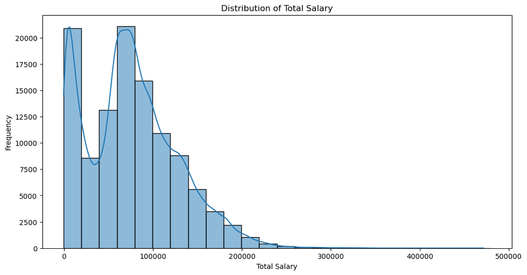

```python
bins = range(int(new_df['TotalPay'].min()), int(new_df['TotalPay'].max()) + 20000, 20000)

plt.figure(figsize=(12, 6))

sb.histplot(new_df['TotalPay'], bins=bins, kde=True)

plt.xlabel('Total Salary')
plt.ylabel('Frequency')
plt.title('Distribution of Total Salary')

plt.show()
```

```
Transit Operator                  7036
Special Nurse                     4389
Registered Nurse                  3736
Public Svc Aide-Public Works      2518
Police Officer 3                  2421
                                  ...
IS Technician Assistant              1
Chief Investment Officer             1
Chief Forensic Toxicologist          1
Lieutenant (Police Department)       1
Cashier 3                            1
Name: JobTitle, Length: 1113, dtype: int64
```

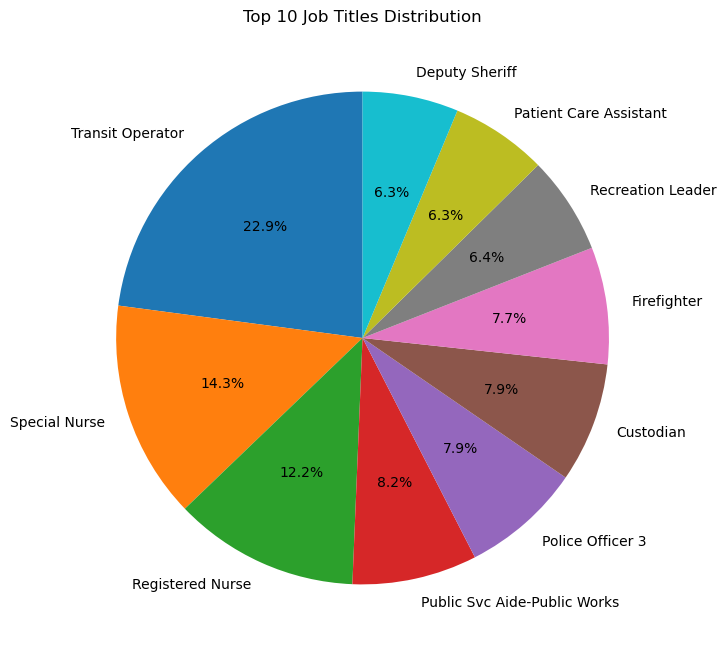

```python
job_title_counts = new_df['JobTitle'].value_counts()

print(job_title_counts)

top_n = 10
top_job_titles = job_title_counts.head(top_n)

plt.figure(figsize = (8, 8))

plt.pie(top_job_titles, labels = top_job_titles.index, autopct = '%1.1f%%', startangle = 90)

plt.title(f'Top {top_n} Job Titles Distribution')

plt.show()
```

# Task 5

```python
grouped_data_1 = new_df.groupby(['JobTitle'])['TotalPay'].mean().reset_index()

grouped_data_1.head()
```

|  | JobTitle | TotalPay |
| --- | --- | --- |
| 0 | ACPO,JuvP, Juv Prob (SFERS) | 62290.780000 |
| 1 | ASR Senior Office Specialist | 63519.363167 |
| 2 | ASR-Office Assistant | 41511.501951 |
| 3 | Account Clerk | 42691.558246 |
| 4 | Accountant I | 62036.101250 |

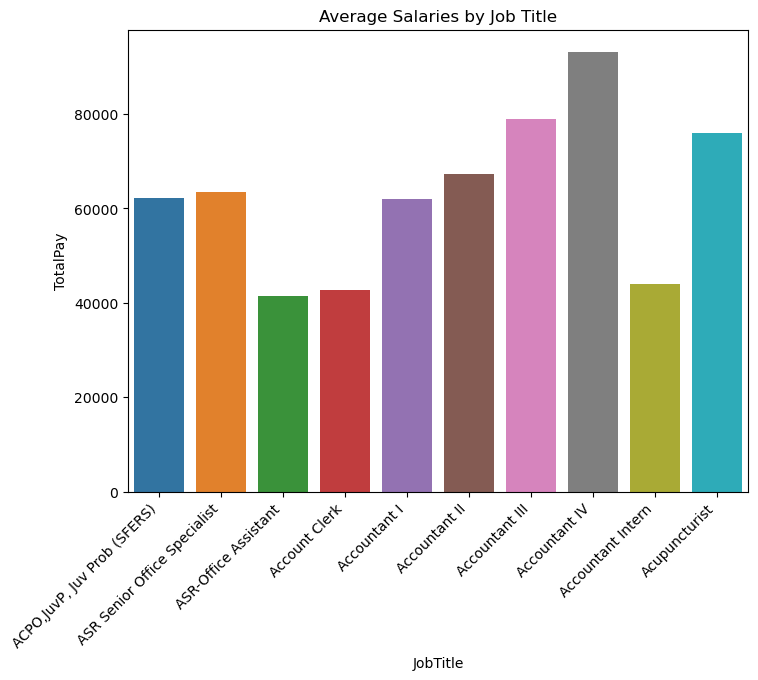

```python
plt.figure(figsize=(8, 6))

sb.barplot(x = 'JobTitle', y = 'TotalPay', data = grouped_data_1.head(10))

plt.title('Average Salaries by Job Title')
plt.xticks(rotation = 45, ha = 'right')

plt.show()
```

```python
grouped_data_2 = new_df.groupby(['EmployeeName', 'Year'])['TotalPay'].mean().reset_index()

grouped_data_2.head()
```

|  | EmployeeName | Year | TotalPay |
| --- | --- | --- | --- |
| 0 | A Bernard Fatooh | 2013 | 23923.62 |
| 1 | A Bernard Fatooh | 2012 | 18500.19 |
| 2 | A Bernard Fatooh | 2014 | 24061.35 |
| 3 | A K Finizio | 2014 | 25854.81 |
| 4 | A. James Robertson Ii | 2013 | 22601.80 |

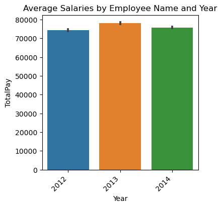

```python
plt.figure(figsize=(4, 4))

sb.barplot(x = 'Year', y = 'TotalPay', data = grouped_data_2)

plt.title('Average Salaries by Employee Name and Year')
plt.xticks(rotation = 45, ha = 'right')

plt.show()
```

# Task 6

```
Correlation between Total Pay and Benefits: 0.8840972255719938
```

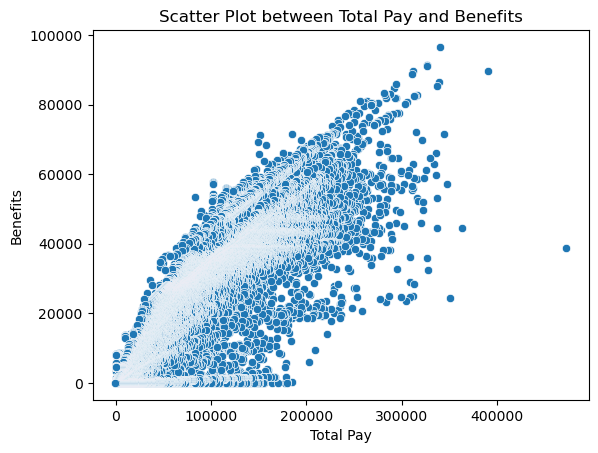

```python
correlation = new_df['TotalPay'].corr(new_df['Benefits'])

print(f'Correlation between Total Pay and Benefits: {correlation}')
print()

sb.scatterplot(x = 'TotalPay', y = 'Benefits', data = new_df)

plt.xlabel('Total Pay')
plt.ylabel('Benefits')
plt.title('Scatter Plot between Total Pay and Benefits')

plt.show()
```

# Task 7

# Report

### Basic Data Exploration:

- The dataset, before handling null values, includes **148,654** samples and **13** features.
- **The column data types are as follows:**
- Id : **int64**
- EmployeeName : **object**
- JobTitle : **object**
- BasePay : **float64**
- OvertimePay : **float64**
- OtherPay : **float64**
- Benefits : **float64**
- TotalPay : **float64**
- TotalPayBenefits : **float64**
- Year : **int64**
- Notes : **float64**
- Agency : **object**
- Status : **float64**
- **Dataset Structure Observations:**
  - All entries in the "Notes" column are null.
  - All entries in the "Status" column are null.
  - The "Benefits" column contains null values.
  - Other columns either have a small number of NaN values or none at all.

### Data Cleaning:

- Removing 'Notes' and 'Status' columns as they contain entirely null values to enhance the clarity of the dataset.
- Due to a substantial number of NaN values in the 'Benefits' column of the initial samples
- traditional techniques for replacing NaN values are deemed impractical.
- Consequently, the corresponding samples (rows) are excluded.
- For the remaining columns with a relatively small number of NaN values
- linear interpolation is applied to fill the missing values.

### Basic Data Visualization:

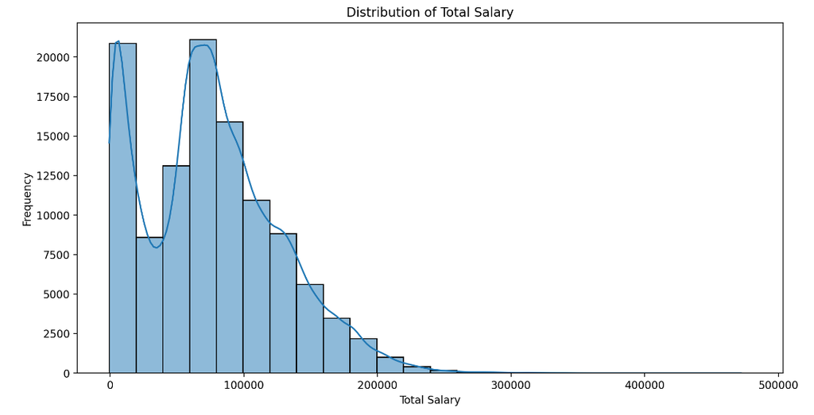

[figure not shown]

**The most 10 frequent job:**

### Grouped Analysis:

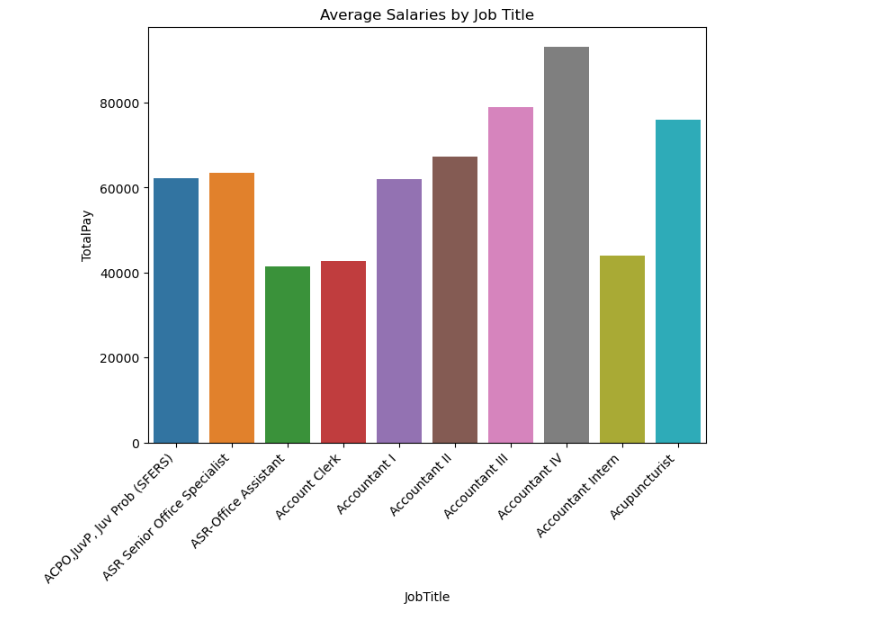

[figure not shown]

### Simple Correlation Analysis:

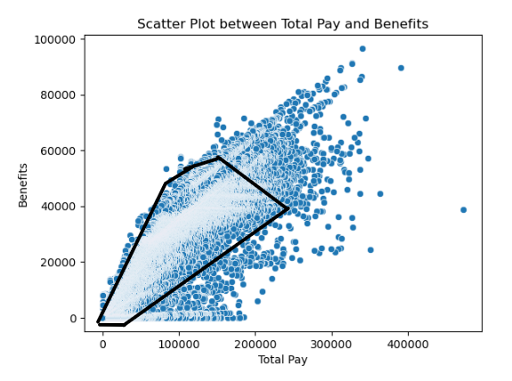

**Observations:**

- I examined the correlation between Benefits and TotalPay.
- The correlation is evident in the marked area of the plot.
- Correlation between Total Pay and Benefits: 0.8840972255719938